# R02_2 Pivot on tp theft

Jilung Hsieh

2019/9/2

# 1 Reading CSV

## 1.1 From the web

- 直接從網路上載入台北市竊盜案資料
- `df <- read.csv(url, fileEncoding = "big5")`這行的意思是把上面那個`url`用`read.csv()`這個函式讀取。讀取的同時，由於一般EXCEL為中文編碼`BIG5`，所以該文件八成是該台北市政單位還用EXCEL在編資料，所以要跟程式碼講說，這個網址所指到的檔案編碼為`BIG5`。
  - `fileEncoding = "big5"`稱為`read.csv()`這個函式的**參數(parameter)。

```r
library(httr)
url <- "http://data.taipei/opendata/datalist/datasetMeta/download?id=68785231-d6c5-47a1-b001-77eec70bec02&rid=34a4a431-f04d-474a-8e72-8d3f586db3df"
df <- read.csv(url, fileEncoding = "big5")
```

## 1.2 Read CSV by read.csv() from local directory

- reading `tp_theft_.csv` in the subfolder `data`
- Remember to use the `fileEncoding` argument to `big5`

```r
# read.csv() to read csv and convert it to a data.frame
df <- read.csv("data/tp_theft.csv", fileEncoding = "big5")

# Checking the strcutrue of it
str(df)
```

```
## 'data.frame':    2436 obs. of  5 variables:
##  $ 編號        : int  1 2 3 4 5 6 7 8 9 10 ...
##  $ 案類        : Factor w/ 1 level "住宅竊盜": 1 1 1 1 1 1 1 1 1 1 ...
##  $ 發生.現.日期: int  780210 951016 970609 990407 991013 991024 991116 1000101 1000825 1001116 ...
##  $ 發生時段    : Factor w/ 16 levels "00~02","01~03",..: 8 14 2 4 16 10 16 8 14 14 ...
##  $ 發生.現.地點: Factor w/ 2250 levels "台北市中山區中山北路1段105巷1~30號",..: 117 417 517 2235 653 1092 505 1737 1469 1824 ...
```

## 1.3 Setting `stringAsFactors`

```r
# Add stringsAsFactors argument  to avoid converting string to factor
df <- read.csv("data/tptheft.csv", fileEncoding = "big5", stringsAsFactors = FALSE)
# double-check the structure of it
str(df)
```

```
## 'data.frame':    2436 obs. of  5 variables:
##  $ 編號        : int  1 2 3 4 5 6 7 8 9 10 ...
##  $ 案類        : chr  "住宅竊盜" "住宅竊盜" "住宅竊盜" "住宅竊盜" ...
##  $ 發生.現.日期: int  780210 951016 970609 990407 991013 991024 991116 1000101 1000825 1001116 ...
##  $ 發生時段    : chr  "10~12" "19~21" "01~03" "04~06" ...
##  $ 發生.現.地點: chr  "台北市中山區新生北路3段31 ~ 60號" "台北市信義區三張里莊敬路341巷1 ~ 30號" "台北市信義區松隆里松山路615巷1 ~ 30號" "台北市萬華區雙園街61 ~ 90號" ...
```

## 1.4 Using `read_csv()` to read the csv

- remember to specify the `locale` argument to `big5`. `locale = locale(encoding = "Big5")`

## 1.5 (Option) Geting a file back to local directory

- 部分Mac電腦無法使用`read.csv()`從網路上取得資料又轉為`data.frame`，一個可行的辦法是先用`GET(url, write_disk("data/tptheft.csv"))`將其取回並命名為`data/tptheft.csv`，之後再用`df <- read.csv("data/tptheft.csv", fileEncoding = "big5", stringsAsFactors = FALSE)`直接讀取該檔案。

```r
library(httr)
GET(url, write_disk("data/tptheft.csv", overwrite = TRUE))
```

```
## Response [https://data.taipei/opendata/datalist/datasetMeta/download?id=68785231-d6c5-47a1-b001-77eec70bec02&rid=34a4a431-f04d-474a-8e72-8d3f586db3df]
##   Date: 2019-09-22 18:15
##   Status: 200
##   Content-Type: text/html; charset=UTF-8
##   Size: 158 kB
## <ON DISK>  /Users/jirlong/Dropbox/Programming/R/R4CSS/data/tptheft.csv
```

```r
df <- read.csv("data/tptheft.csv", fileEncoding = "big5", stringsAsFactors = FALSE)
```

# 2 Inspecting data

```r
# View(df)
head(df)    # get first part of the data.frame
```

```
##   編號     案類 發生.現.日期 發生時段
## 1    1 住宅竊盜       780210    10~12
## 2    2 住宅竊盜       951016    19~21
## 3    3 住宅竊盜       970609    01~03
## 4    4 住宅竊盜       990407    04~06
## 5    5 住宅竊盜       991013    22~24
## 6    6 住宅竊盜       991024    13~15
##                            發生.現.地點
## 1      台北市中山區新生北路3段31 ~ 60號
## 2 台北市信義區三張里莊敬路341巷1 ~ 30號
## 3 台北市信義區松隆里松山路615巷1 ~ 30號
## 4           台北市萬華區雙園街61 ~ 90號
## 5      台北市內湖區成功路4段331 ~ 360號
## 6  台北市南港區東新里興南街52巷1 ~ 30號
```

```r
class(df)
```

```
## [1] "data.frame"
```

```r
str(df)
```

```
## 'data.frame':    2436 obs. of  5 variables:
##  $ 編號        : int  1 2 3 4 5 6 7 8 9 10 ...
##  $ 案類        : chr  "住宅竊盜" "住宅竊盜" "住宅竊盜" "住宅竊盜" ...
##  $ 發生.現.日期: int  780210 951016 970609 990407 991013 991024 991116 1000101 1000825 1001116 ...
##  $ 發生時段    : chr  "10~12" "19~21" "01~03" "04~06" ...
##  $ 發生.現.地點: chr  "台北市中山區新生北路3段31 ~ 60號" "台北市信義區三張里莊敬路341巷1 ~ 30號" "台北市信義區松隆里松山路615巷1 ~ 30號" "台北市萬華區雙園街61 ~ 90號" ...
```

```r
summary(df)
```

```
##       編號            案類            發生.現.日期       發生時段
##  Min.   :   1.0   Length:2436        Min.   : 780210   Length:2436
##  1st Qu.: 609.8   Class :character   1st Qu.:1041217   Class :character
##  Median :1218.5   Mode  :character   Median :1051113   Mode  :character
##  Mean   :1218.5                      Mean   :1055836
##  3rd Qu.:1827.2                      3rd Qu.:1070205
##  Max.   :2436.0                      Max.   :1080824
##  發生.現.地點
##  Length:2436
##  Class :character
##  Mode  :character
##
##
##
```

```r
# look up help
help(summary)
?summary
```

## 2.1 Dimension

e.g., dim(), ncol(), nrow(),length()

```r
dim(df)
```

```
## [1] 2436    5
```

```r
ncol(df)
```

```
## [1] 5
```

```r
nrow(df)
```

```
## [1] 2436
```

```r
length(df)
```

```
## [1] 5
```

## 2.2 Variable names

- `names(df)` 列出變數名稱
- `df$發生.現.地點` 顯示該變數內容
- `df$發生時段` 顯示該變數內容
- `length(df$發生時段)` 顯示該變數的長度（相當於有幾個）

```r
names(df)
```

```
## [1] "編號"         "案類"         "發生.現.日期" "發生時段"
## [5] "發生.現.地點"
```

```r
head(df$發生.現.地點)
```

```
## [1] "台北市中山區新生北路3段31 ~ 60號"
## [2] "台北市信義區三張里莊敬路341巷1 ~ 30號"
## [3] "台北市信義區松隆里松山路615巷1 ~ 30號"
## [4] "台北市萬華區雙園街61 ~ 90號"
## [5] "台北市內湖區成功路4段331 ~ 360號"
## [6] "台北市南港區東新里興南街52巷1 ~ 30號"
```

```r
head(df$發生時段)
```

```
## [1] "10~12" "19~21" "01~03" "04~06" "22~24" "13~15"
```

```r
length(df$發生時段)
```

```
## [1] 2436
```

# 3 Cleaning data

- 目標：「發生時段」我打算取出前面的數字來代表時間就好，「發生地點」我打算只取出行政區名，其他地址不要。邏輯上，我要把那串字取出第x個字到第y個字，所以要用`substr()`這個函式，或者未來會教到的`stringr::str_sub()`函式。
- 用`?substr`查詢其用法和意義。相當於`getting sub string since x to y`。

```r
# Get substring of var "發生時段" and assign to a new time var
df$time <- substr(df$發生時段, 1, 2)


# Get substring of var "發生.現.地點" and assign to a new region var
df$region <- substr(df$發生.現.地點, 4, 5)
```

# 4 Pivot analysis: Counting and Summarizing

- 我們要回答的第一個數據問題通常是，那XXX的案例有幾個？例如大安區有多少竊盜案？買超過10000元訂單的客戶有多少人？男生和女生會修程式課的個別有多少人？這稱為計數。

## 4.1 Counting single variable by table()

```r
# counting the frequency of time variable
table(df$time)
```

```
##
##  00  01  02  04  06  07  08  10  12  13  14  16  18  19  20  22
##  30 167  61 175  42 232  44 384  59 254  60 281  61 250  55 281
```

```r
# counting the frequency of region variable
table(df$region)
```

```
##
## 三重 中和 中山 中正 信義 內湖 北投 南港 士林 大同 大安 文山 松山 板橋 淡水
##    5    2  303  175  155  225  266  137  265  131  221  159  158    5    1
## 萬華
##  228
```

## 4.2 Counting by tapply()

- Using `length()` as counting method

```r
# tapply() one arbitrary var by var time with length() function
tapply(df$編號, df$time, length)
```

```
##  00  01  02  04  06  07  08  10  12  13  14  16  18  19  20  22
##  30 167  61 175  42 232  44 384  59 254  60 281  61 250  55 281
```

```r
# tapply() one arbitrary var by var region with length() function
tapply(df$編號, df$region, length)
```

```
## 三重 中和 中山 中正 信義 內湖 北投 南港 士林 大同 大安 文山 松山 板橋 淡水
##    5    2  303  175  155  225  266  137  265  131  221  159  158    5    1
## 萬華
##  228
```

# 5 Filtering data

```r
# filter out irrelevant timestamp
df <- df[!df$time %in% c("00", "02", "06", "08", "12", "14" ,"18", "20"), ]

# filter out irrelevant region(area)
df <- df[!df$region %in% c("三重", "中和", "淡水", "板橋"), ]
```

# 6 Pivot analysis on 2 vars

## 6.1 by `table()` with 2 independent vars

```r
# Tabulating time and region variables
res_table <- table(df$time, df$region)

# Checking it class and its content
class(res_table)
```

```
## [1] "table"
```

```r
res_table
```

```
##
##      中山 中正 信義 內湖 北投 南港 士林 大同 大安 文山 松山 萬華
##   01   27   12   10   11   21    7   27   12    8   11    8   13
##   04   22   11   12   20   19    7   15   15   12   10    7   23
##   07   30   17   12   25   16   17   20   15   22   17   18   23
##   10   37   30   18   37   43   20   37   16   45   27   40   34
##   13   23   13   17   31   35   10   34   16   26   15   15   19
##   16   23   22   15   25   44   14   34   14   29   17   17   27
##   19   36   20   18   23   15   13   35   10   15   14   22   29
##   22   58   26   28   25   19   14   25    9   19   25   14   19
```

## 6.2 by `tapply()` with 2 independent vars

```r
res_tapply <- tapply(df$編號, list(df$time, df$region), length)
class(res_tapply)
```

```
## [1] "matrix"
```

```r
res_tapply
```

```
##    中山 中正 信義 內湖 北投 南港 士林 大同 大安 文山 松山 萬華
## 01   27   12   10   11   21    7   27   12    8   11    8   13
## 04   22   11   12   20   19    7   15   15   12   10    7   23
## 07   30   17   12   25   16   17   20   15   22   17   18   23
## 10   37   30   18   37   43   20   37   16   45   27   40   34
## 13   23   13   17   31   35   10   34   16   26   15   15   19
## 16   23   22   15   25   44   14   34   14   29   17   17   27
## 19   36   20   18   23   15   13   35   10   15   14   22   29
## 22   58   26   28   25   19   14   25    9   19   25   14   19
```

```r
# View(res)
```

# 7 Pivot by dplyr::count()

```r
# counting by dplyr::count()
res_count <- dplyr::count(df, time, region)
class(res_count)
```

```
## [1] "tbl_df"     "tbl"        "data.frame"
```

```r
res_count
```

```
## # A tibble: 96 x 3
##    time  region     n
##    <chr> <chr>  <int>
##  1 01    中山      27
##  2 01    中正      12
##  3 01    信義      10
##  4 01    內湖      11
##  5 01    北投      21
##  6 01    南港       7
##  7 01    士林      27
##  8 01    大同      12
##  9 01    大安       8
## 10 01    文山      11
## # ... with 86 more rows
```

```r
# spreading the region into columns
res_count_spread <- tidyr::spread(res_count, region, n, fill = 0)
res_count_spread
```

```
## # A tibble: 8 x 13
##   time   中山  中正  信義  內湖  北投  南港  士林  大同  大安  文山  松山
##   <chr> <dbl> <dbl> <dbl> <dbl> <dbl> <dbl> <dbl> <dbl> <dbl> <dbl> <dbl>
## 1 01       27    12    10    11    21     7    27    12     8    11     8
## 2 04       22    11    12    20    19     7    15    15    12    10     7
## 3 07       30    17    12    25    16    17    20    15    22    17    18
## 4 10       37    30    18    37    43    20    37    16    45    27    40
## 5 13       23    13    17    31    35    10    34    16    26    15    15
## 6 16       23    22    15    25    44    14    34    14    29    17    17
## 7 19       36    20    18    23    15    13    35    10    15    14    22
## 8 22       58    26    28    25    19    14    25     9    19    25    14
## # ... with 1 more variable: 萬華 <dbl>
```

```r
# ??dplyr::count
```

# 8 Plotting

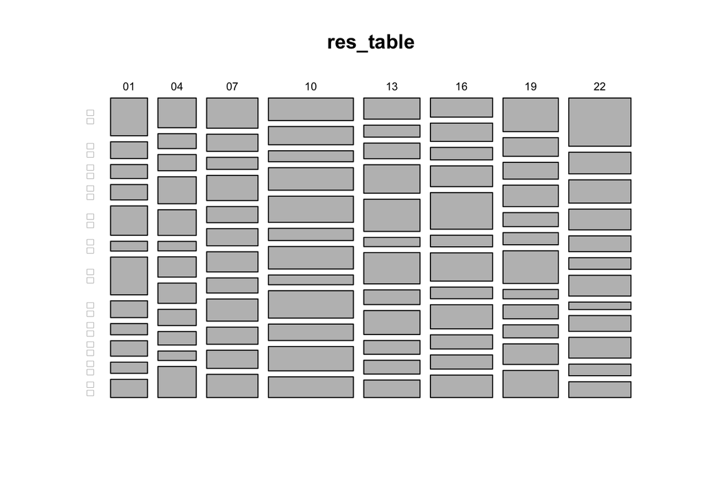

```r
# mosaicplot() to plot 2-dim categorical vars.
mosaicplot(res_table)
```

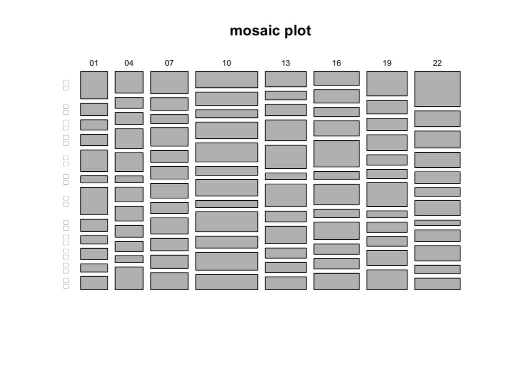

```r
# Add argument main (figure title)
mosaicplot(res_table, main="mosaic plot")
```

## 8.1 (Option) Cannot show Chinese?

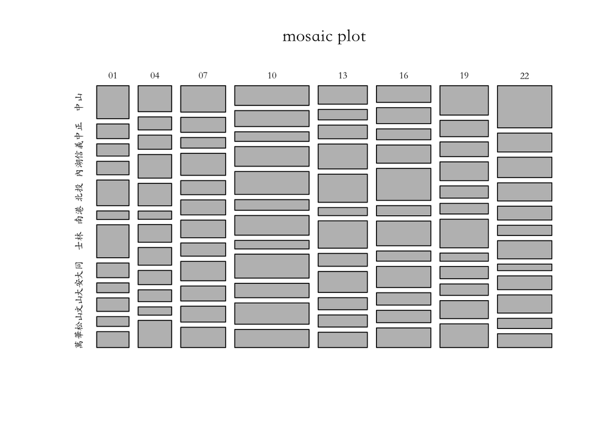

```r
par(family=('Heiti TC Light'))
par(family=('STKaiti'))
mosaicplot(res_table, main="mosaic plot")
```

## 8.2 (Option) Self-defined color?

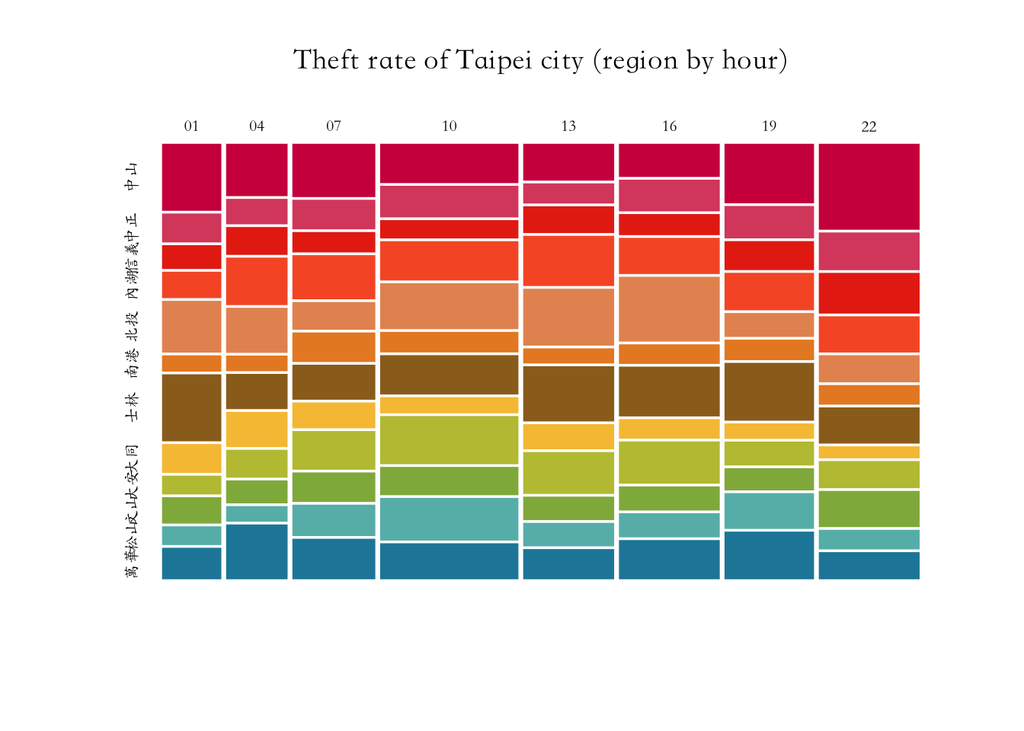

```r
# Set up color by yourself.
colors <- c('#D0104C', '#DB4D6D', '#E83015',  '#F75C2F',
            '#E79460', '#E98B2A', '#9B6E23', '#F7C242',
            '#BEC23F', '#90B44B', '#66BAB7', '#1E88A8')
par(family=('STKaiti'))
mosaicplot(res_table, color=colors, border=0, off = 3,
           main="Theft rate of Taipei city (region by hour)")
```

# 9 Practices

## 9.1 Practice02_2_1

- Check what happens if you swap the time and region in tapply()
- does it possible to extract month by substr()?
- (you may need to search how to extract the last n characters in R)

```r
x <- df$發生.現.日期
df$month <- substr(x, 3, 4) # is this correct? Try to modify it!
# res2 <- tapply(df$編號, list(df$month, df$region), length)
# res2 <- tapply(df$編號, list(df$region, df$month), length)
# mosaicplot(res2, color=colors, border=0, off = 3, main="Theft rate of Taipei city (region by hour)")
```

## 9.2 Practice02_2_2

- Reading maternal leave data
- Summarize the last year data by world region

# 10 (dplyr) on tp theft

```r
# readr::guess_encoding("data/tp_theft.csv")
library(readr)
library(tidyverse)
df <- read_csv("data/tp_theft.csv", locale = locale(encoding = "Big5")) %>%
    select(id = 編號,
           cat = 案類,
           date = `發生(現)日期`,
           time = `發生時段`,
           location = `發生(現)地點`) %>% # glimpse()
    mutate(year = date %/% 10000) %>%
    mutate(month = date %/% 100 %% 100) %>%
    mutate(location = stringr::str_sub(location, 4, 6)) %>%
    # count(year) %>% View
    filter(year >= 104) %>%
    # count(time) %>% View
    filter(!time %in% c("00~02", "02~04", "06~08", "08~10", "12~14")) %>%
    # count(location) %>%
    filter(!location %in% c("中和市", "板橋市")) %>%
    count(time, location) %>%
    spread(location, n, fill=0)
```

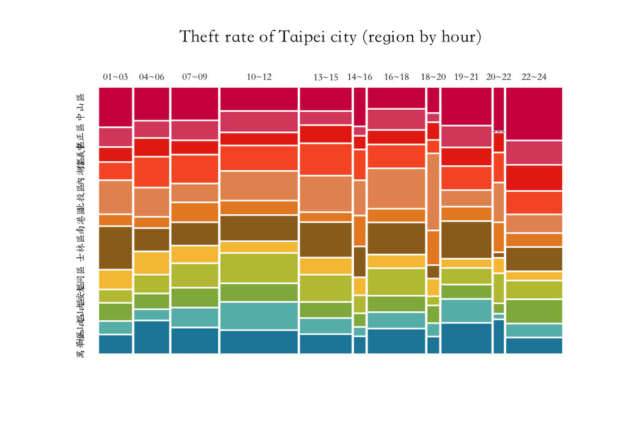

```r
par(family=('STKaiti'))
row.names(df) <- df$time
df$time <- NULL
colors <- c('#D0104C', '#DB4D6D', '#E83015',  '#F75C2F',
            '#E79460', '#E98B2A', '#9B6E23', '#F7C242',
            '#BEC23F', '#90B44B', '#66BAB7', '#1E88A8')
mosaicplot(df, color=colors, border=0, off = 3, main="Theft rate of Taipei city (region by hour)")
```